# Cronbach Alpha for Employees

Namit Bhatnagar

2024-05-15

```r
library(readxl)
Bank_Employee_Data_Sets <- read_excel("C:/Users/namit/Downloads/Bank Employee Data Sets.xlsx",
                                      sheet = "Responses")
View(Bank_Employee_Data_Sets)
Data = Bank_Employee_Data_Sets
C01 = Data$Q1
C02 = Data$Q2
C03 = Data$Q3
C04 = Data$Q4
C05 = Data$Q5
C06 = Data$Q6
C07 = Data$Q7
C08 = Data$Q8
C09 = Data$Q9
C10 = Data$Q10
C11 = Data$Q11
C12 = Data$Q12
C13 = Data$Q13
C14 = Data$Q14
```

# **CRONBACH’S ALPHA**

```r
Cron = data.frame(C01, C02, C03, C04, C05, C06, C07, C08, C09, C10, C11, C12, C13, C14)
library(psych)
alpha(Cron, check.keys = TRUE)
```

```
##
## Reliability analysis
## Call: alpha(x = Cron, check.keys = TRUE)
##
##   raw_alpha std.alpha G6(smc) average_r S/N  ase mean   sd median_r
##       0.94      0.92    0.95      0.44  11 0.01  3.2 0.86     0.53
##
##     95% confidence boundaries
##          lower alpha upper
## Feldt     0.91  0.94  0.95
## Duhachek  0.92  0.94  0.95
##
##  Reliability if an item is dropped:
##      raw_alpha std.alpha G6(smc) average_r  S/N alpha se  var.r med.r
## C01       0.93      0.91    0.94      0.42  9.6   0.0110 0.0891  0.53
## C02       0.93      0.91    0.94      0.43  9.7   0.0109 0.0878  0.53
## C03       0.93      0.91    0.94      0.43  9.7   0.0109 0.0903  0.53
## C04       0.93      0.90    0.93      0.42  9.5   0.0114 0.0846  0.53
## C05       0.93      0.91    0.94      0.43 10.0   0.0107 0.0894  0.53
## C06-      0.94      0.94    0.96      0.55 15.9   0.0094 0.0071  0.55
## C07       0.93      0.91    0.94      0.43  9.8   0.0109 0.0895  0.53
## C08       0.93      0.91    0.94      0.43  9.8   0.0108 0.0903  0.53
## C09       0.93      0.91    0.94      0.43  9.6   0.0110 0.0897  0.53
## C10       0.93      0.91    0.94      0.43  9.7   0.0111 0.0872  0.53
## C11       0.93      0.91    0.94      0.43  9.9   0.0108 0.0885  0.53
## C12       0.93      0.91    0.94      0.43  9.9   0.0107 0.0895  0.53
## C13       0.93      0.91    0.94      0.43  9.9   0.0108 0.0873  0.53
## C14       0.93      0.91    0.94      0.43  9.9   0.0108 0.0860  0.53
##
##  Item statistics
##       n raw.r std.r r.cor r.drop mean  sd
## C01  87  0.78  0.80  0.79   0.74  3.0 1.2
## C02  87  0.77  0.77  0.77   0.72  3.1 1.2
## C03  87  0.76  0.78  0.76   0.71  3.3 1.2
## C04  87  0.84  0.81  0.81   0.80  3.1 1.3
## C05  87  0.72  0.72  0.70   0.67  3.2 1.1
## C06- 87  0.39 -0.21 -0.30   0.31  2.7 1.1
## C07  87  0.75  0.75  0.73   0.70  3.1 1.2
## C08  87  0.74  0.75  0.72   0.70  3.2 1.2
## C09  87  0.77  0.79  0.78   0.73  3.7 1.1
## C10  87  0.79  0.79  0.77   0.75  3.1 1.1
## C11  87  0.74  0.73  0.71   0.70  3.2 1.1
## C12  87  0.73  0.74  0.72   0.68  3.2 1.1
## C13  87  0.75  0.74  0.72   0.71  3.3 1.1
## C14  87  0.75  0.73  0.73   0.71  3.2 1.2
##
## Non missing response frequency for each item
##        1    2    3    4    5 miss
## C01 0.13 0.16 0.37 0.23 0.11    0
## C02 0.13 0.18 0.23 0.33 0.13    0
## C03 0.09 0.15 0.29 0.30 0.17    0
## C04 0.17 0.11 0.33 0.18 0.20    0
## C05 0.08 0.18 0.34 0.24 0.15    0
## C06 0.06 0.16 0.38 0.25 0.15    0
## C07 0.11 0.18 0.28 0.29 0.14    0
## C08 0.09 0.16 0.33 0.28 0.14    0
## C09 0.08 0.05 0.24 0.38 0.25    0
## C10 0.08 0.21 0.33 0.24 0.14    0
## C11 0.08 0.16 0.34 0.29 0.13    0
## C12 0.08 0.15 0.36 0.31 0.10    0
## C13 0.07 0.15 0.37 0.29 0.13    0
## C14 0.07 0.20 0.32 0.25 0.16    0
```

Reliability analysis for questionnaires ensures that the data collected is consistent, trustworthy, and suitable for the intended purpose Reliability analysis helps assess the internal consistency of the questionnaire items. This means examining whether the questions in the questionnaire are measuring the same underlying construct or concept. If there are inconsistencies, it could lead to unreliable results.Cronbach’s alpha ranges from 0 to 1. Higher values indicate greater internal consistency reliability.

Generally, alpha values above 0.7 are considered acceptable for research purposes, though the threshold may vary depending on the context.

A value below 0.7 may indicate that the items in the questionnaire are not sufficiently related to one another or that the questionnaire measures multiple constructs rather than a single underlying construct.

# **NORMALITY TESTS**

```r
library(tseries)
jarque.bera.test(C01)
```

```
##
##  Jarque Bera Test
##
## data:  C01
## X-squared = 1.8809, df = 2, p-value = 0.3905
```

```r
jarque.bera.test(C02)
```

```
##
##  Jarque Bera Test
##
## data:  C02
## X-squared = 4.3834, df = 2, p-value = 0.1117
```

```r
jarque.bera.test(C03)
```

```
##
##  Jarque Bera Test
##
## data:  C03
## X-squared = 3.4226, df = 2, p-value = 0.1806
```

```r
jarque.bera.test(C04)
```

```
##
##  Jarque Bera Test
##
## data:  C04
## X-squared = 3.8815, df = 2, p-value = 0.1436
```

```r
jarque.bera.test(C05)
```

```
##
##  Jarque Bera Test
##
## data:  C05
## X-squared = 1.9392, df = 2, p-value = 0.3792
```

```r
jarque.bera.test(C06)
```

```
##
##  Jarque Bera Test
##
## data:  C06
## X-squared = 1.2283, df = 2, p-value = 0.5411
```

```r
jarque.bera.test(C07)
```

```
##
##  Jarque Bera Test
##
## data:  C07
## X-squared = 3.3843, df = 2, p-value = 0.1841
```

```r
jarque.bera.test(C08)
```

```
##
##  Jarque Bera Test
##
## data:  C08
## X-squared = 2.267, df = 2, p-value = 0.3219
```

```r
jarque.bera.test(C09)
```

```
##
##  Jarque Bera Test
##
## data:  C09
## X-squared = 10.296, df = 2, p-value = 0.005812
```

```r
jarque.bera.test(C10)
```

```
##
##  Jarque Bera Test
##
## data:  C10
## X-squared = 2.021, df = 2, p-value = 0.364
```

```r
jarque.bera.test(C11)
```

```
##
##  Jarque Bera Test
##
## data:  C11
## X-squared = 1.9299, df = 2, p-value = 0.381
```

```r
jarque.bera.test(C12)
```

```
##
##  Jarque Bera Test
##
## data:  C12
## X-squared = 2.0236, df = 2, p-value = 0.3636
```

```r
jarque.bera.test(C13)
```

```
##
##  Jarque Bera Test
##
## data:  C13
## X-squared = 1.513, df = 2, p-value = 0.4693
```

```r
jarque.bera.test(C14)
```

```
##
##  Jarque Bera Test
##
## data:  C14
## X-squared = 2.32, df = 2, p-value = 0.3135
```

The Jarque-Bera test is a test of the skewness and kurtosis of a distribution, and it tests the null hypothesis that the data come from a normal distribution.

## Conclusion

Here are the results of the Jarque-Bera tests for each variable:

For most variables (C01 to C14), the p-values are greater than the significance level of 0.05, indicating that there is no significant departure from normality. This suggests that these variables may follow a normal distribution.

However, for variable C09, the p-value is 0.005812, which is less than 0.05. This suggests that there is a significant departure from normality for this variable.

In summary, most of the variables in your data set appear to have distributions that are not significantly different from normal, except for variable C09, which may have a non-normal distribution. It’s important to interpret these results in the context of your analysis and consider whether any departures from normality could affect the validity of your statistical tests or conclusions.

# **Parametric Test Applicable**

```r
t.test(C01)
```

```
##
##  One Sample t-test
##
## data:  C01
## t = 24.274, df = 86, p-value < 2.2e-16
## alternative hypothesis: true mean is not equal to 0
## 95 percent confidence interval:
##  2.796520 3.295434
## sample estimates:
## mean of x
##  3.045977
```

```r
t.test(C02)
```

```
##
##  One Sample t-test
##
## data:  C02
## t = 23.796, df = 86, p-value < 2.2e-16
## alternative hypothesis: true mean is not equal to 0
## 95 percent confidence interval:
##  2.886323 3.412527
## sample estimates:
## mean of x
##  3.149425
```

```r
t.test(C03)
```

```
##
##  One Sample t-test
##
## data:  C03
## t = 25.858, df = 86, p-value < 2.2e-16
## alternative hypothesis: true mean is not equal to 0
## 95 percent confidence interval:
##  3.055852 3.564837
## sample estimates:
## mean of x
##  3.310345
```

```r
t.test(C04)
```

```
##
##  One Sample t-test
##
## data:  C04
## t = 21.793, df = 86, p-value < 2.2e-16
## alternative hypothesis: true mean is not equal to 0
## 95 percent confidence interval:
##  2.830806 3.399079
## sample estimates:
## mean of x
##  3.114943
```

```r
t.test(C05)
```

```
##
##  One Sample t-test
##
## data:  C05
## t = 25.924, df = 86, p-value < 2.2e-16
## alternative hypothesis: true mean is not equal to 0
## 95 percent confidence interval:
##  2.950365 3.440439
## sample estimates:
## mean of x
##  3.195402
```

```r
t.test(C06)
```

```
##
##  One Sample t-test
##
## data:  C06
## t = 28.142, df = 86, p-value < 2.2e-16
## alternative hypothesis: true mean is not equal to 0
## 95 percent confidence interval:
##  3.044460 3.507264
## sample estimates:
## mean of x
##  3.275862
```

```r
t.test(C07)
```

```
##
##  One Sample t-test
##
## data:  C07
## t = 24.168, df = 86, p-value < 2.2e-16
## alternative hypothesis: true mean is not equal to 0
## 95 percent confidence interval:
##  2.890370 3.408481
## sample estimates:
## mean of x
##  3.149425
```

```r
t.test(C08)
```

```
##
##  One Sample t-test
##
## data:  C08
## t = 25.949, df = 86, p-value < 2.2e-16
## alternative hypothesis: true mean is not equal to 0
## 95 percent confidence interval:
##  2.961216 3.452577
## sample estimates:
## mean of x
##  3.206897
```

```r
t.test(C09)
```

```
##
##  One Sample t-test
##
## data:  C09
## t = 29.931, df = 86, p-value < 2.2e-16
## alternative hypothesis: true mean is not equal to 0
## 95 percent confidence interval:
##  3.433868 3.922454
## sample estimates:
## mean of x
##  3.678161
```

```r
t.test(C10)
```

```
##
##  One Sample t-test
##
## data:  C10
## t = 25.621, df = 86, p-value < 2.2e-16
## alternative hypothesis: true mean is not equal to 0
## 95 percent confidence interval:
##  2.905058 3.393792
## sample estimates:
## mean of x
##  3.149425
```

```r
t.test(C11)
```

```
##
##  One Sample t-test
##
## data:  C11
## t = 26.931, df = 86, p-value < 2.2e-16
## alternative hypothesis: true mean is not equal to 0
## 95 percent confidence interval:
##  2.980826 3.455955
## sample estimates:
## mean of x
##  3.218391
```

```r
t.test(C12)
```

```
##
##  One Sample t-test
##
## data:  C12
## t = 27.701, df = 86, p-value < 2.2e-16
## alternative hypothesis: true mean is not equal to 0
## 95 percent confidence interval:
##  2.976757 3.437036
## sample estimates:
## mean of x
##  3.206897
```

```r
t.test(C13)
```

```
##
##  One Sample t-test
##
## data:  C13
## t = 28.076, df = 86, p-value < 2.2e-16
## alternative hypothesis: true mean is not equal to 0
## 95 percent confidence interval:
##  3.022549 3.483198
## sample estimates:
## mean of x
##  3.252874
```

```r
t.test(C14)
```

```
##
##  One Sample t-test
##
## data:  C14
## t = 26.267, df = 86, p-value < 2.2e-16
## alternative hypothesis: true mean is not equal to 0
## 95 percent confidence interval:
##  2.996070 3.486689
## sample estimates:
## mean of x
##  3.241379
```

On conducting one-sample t-tests for each of the variables (C01 to C14) in your data set. The purpose of these tests is to determine whether the mean of each variable significantly differs from zero.

Here are the results of the one-sample t-tests for each variable:

For each variable, the t-values are large and the p-values are extremely small (p < 2.2e-16), indicating strong evidence against the null hypothesis that the mean is equal to zero.

The confidence intervals for the mean of each variable do not include zero. This further supports the rejection of the null hypothesis.

In summary, the results suggest that the means of all variables (C01 to C14) are significantly different from zero. This indicates that the sample means are significantly greater than zero for each variable.

## **HYPOTHESIS ANALYSIS VARIABLE WISE**

### OBJECTIVE 1: To assess the awareness and implementation of Green Banking Initiatives among Bank Employees (Independent)

`ACHIEVED OBJECTIVE 1`

Bank Employees are aware about the implementation of Green Banking Initiatives.

#### VARIABLE 1: Awareness of Green Banking Incentives and Initiatives

`p-value < 0.05 (rejecting Null Hypothesis)`

- H0a = Employees are not aware about their Green Banking Incentives and Initiatives.
- H1a = Employees are aware about their Green Banking Incentives and Initiatives.

#### VARIABLE 2: Understanding and Importance of Green Banking

`p-value < 0.05 (rejecting Null Hypothesis)`

- H0b = Employees do not understand the concept and importance of Green Banking
- H1b = Employees understand the concept and importance of Green Banking.

#### VARIABLE 3: Prioritizing Green Banking Initiatives

`p-value < 0.05 (rejecting Null Hypothesis)`

- H0c = Employees do not prioritize Green Banking initiatives.
- H1c = Employees prioritize Green Banking initiatives.

#### VARIABLE 4: Training and Information about Green Banking

`p-value < 0.05 (rejecting Null Hypothesis)`

- H0d = Employees do not receive training and information about Green Banking.
- H1d = Employees receive training and information about Green Banking.

#### VARIABLE 5: Stakeholder’s Influence on Green Banking Initiatives

`p-value < 0.05 (rejecting Null Hypothesis)`

- H0e = Stakeholders do not have influence on Green Banking Initiatives.
- H1e = Stakeholders have influence on Green Banking Initiatives.

#### VARIABLE 6: Difficulty to implement Green Banking Initiatives

`p-value < 0.05 (rejecting Null Hypothesis)`

- H0f = Banks do not have any difficulty to implement Green Banking Initiatives.
- H1f = Banks have any difficulty to implement Green Banking Initiatives.

#### VARIABLE 7: Engagement in Cross-Departmental Consultation and Collaboration for Green Banking Initiatives

`p-value < 0.05 (rejecting Null Hypothesis)`

- H0g = Banks do not engage in cross-departmental consultation and collaboration for Green Banking Initiatives.
- H1g = Banks engage in cross-departmental consultation and collaboration for Green Banking Initiatives.

#### VARIABLE 8: Bank’s Investment in Education and Training related to Green Banking.

`p-value < 0.05 (rejecting Null Hypothesis)`

- H0h = Banks do not invest significantly in education and training related to Green Banking Initiatives.
- H1h = Banks invest significantly in education and training related to Green Banking Initiatives.

#### VARIABLE 9: Promoting Green Banking products to Customers

`p-value < 0.05 (rejecting Null Hypothesis)`

- H0i = Bank employees are not likely to promote Green Banking products to the customers.
- H1i = Bank employees are likely to promote Green Banking products to the customers.

### OBJECTIVE 2: To identify the types of Green Banking Initiatives offered by banks to customers (Independent)

`ACHIEVED OBJECTIVE 2`

Green Banking Initiatives includes Lower Interest Rates on Loans for Green Projects and Products, Cashback or Discounts for customers investing in Green Product, Waived or reduced Processing Fees for Green Loans or Investments, Extended repayment tenures for loans on Green Projects or Products, Added incentives for Green Products.

#### VARIABLE 10: Offering Lower Interest Rates on Loans for Green Projects and Products

`p-value < 0.05 (rejecting Null Hypothesis)`

- H0a = Bank do not offer lower interest rates on loans for Green Projects and Products.
- H1a = Bank offer lower interest rates on loans for Green Projects and Products.

#### VARIABLE 11: Providing Cashback or Discounts for customers investing in Green Products

`p-value < 0.05 (rejecting Null Hypothesis)`

- H0b = Banks do not provide cashback or discounts for customers who invest in green products.
- H1b = Banks provide cashback or discounts for customers who invest in green products.

#### VARIABLE 12: Waived or reduced Processing Fees for Green Loans or Investments

`p-value < 0.05 (rejecting Null Hypothesis)`

- H0c = Banks do not waive or reduce processing fees for green loans or investments.
- H1c = Banks waive or reduce processing fees for green loans or investments.

#### VARIABLE 13: Extended repayment tenures for loans on Green Projects or Products

`p-value < 0.05 (rejecting Null Hypothesis)`

- H0d = Banks do not offer extended repayment tenures for loans on green projects or products.
- H1d = Banks offer extended repayment tenures for loans on green projects or products.

#### VARIABLE 14: Added incentives for Green Products

`p-value < 0.05 (rejecting Null Hypothesis)`

- H0e = Banks do not have any other specific green banking incentives for customers.
- H1e = Banks have any other specific green banking incentives for customers.

# **MULTIPLE REGRESSION ANALYSIS**

```r
model <- lm(C02 + C03 + C04 + C05 + C06 + C07 + C08 + C09 ~ C01, data = Data)
summary(model)
```

```
##
## Call:
## lm(formula = C02 + C03 + C04 + C05 + C06 + C07 + C08 + C09 ~
##     C01, data = Data)
##
## Residuals:
##     Min      1Q  Median      3Q     Max
## -9.8812 -1.8812  0.1188  2.4516 11.4534
##
## Coefficients:
##             Estimate Std. Error t value Pr(>|t|)
## (Intercept)  12.8776     1.2480   10.32   <2e-16 ***
## C01           4.3345     0.3827   11.32   <2e-16 ***
## ---
## Signif. codes:  0 '***' 0.001 '**' 0.01 '*' 0.05 '.' 0.1 ' ' 1
##
## Residual standard error: 4.154 on 85 degrees of freedom
## Multiple R-squared:  0.6014, Adjusted R-squared:  0.5967
## F-statistic: 128.3 on 1 and 85 DF,  p-value: < 2.2e-16
```

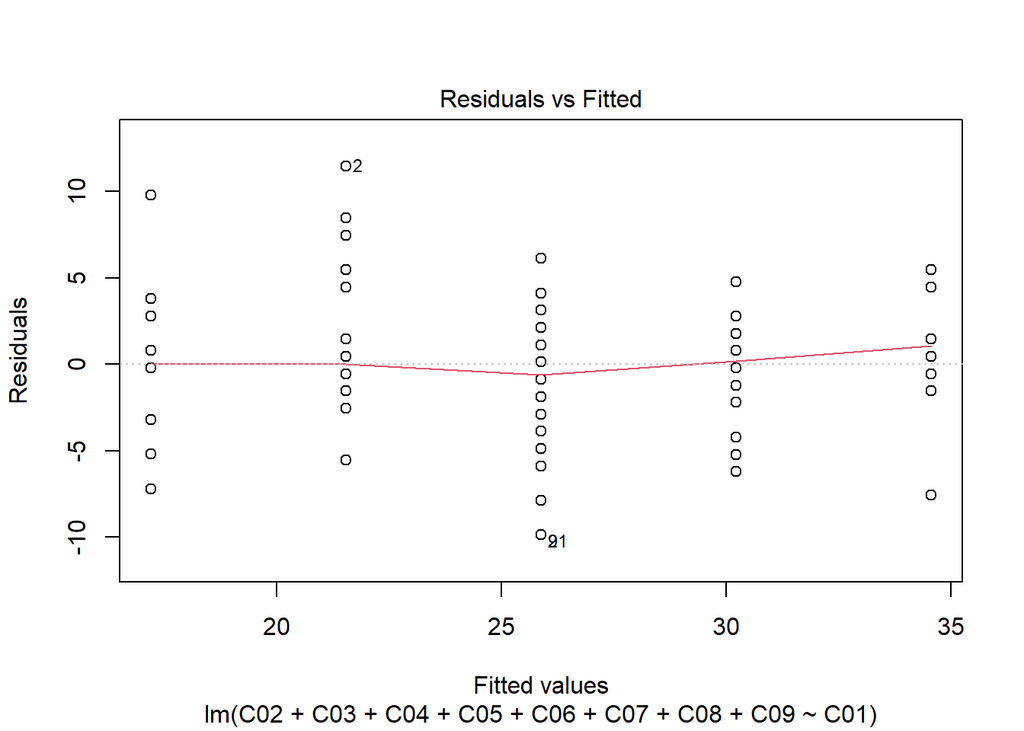

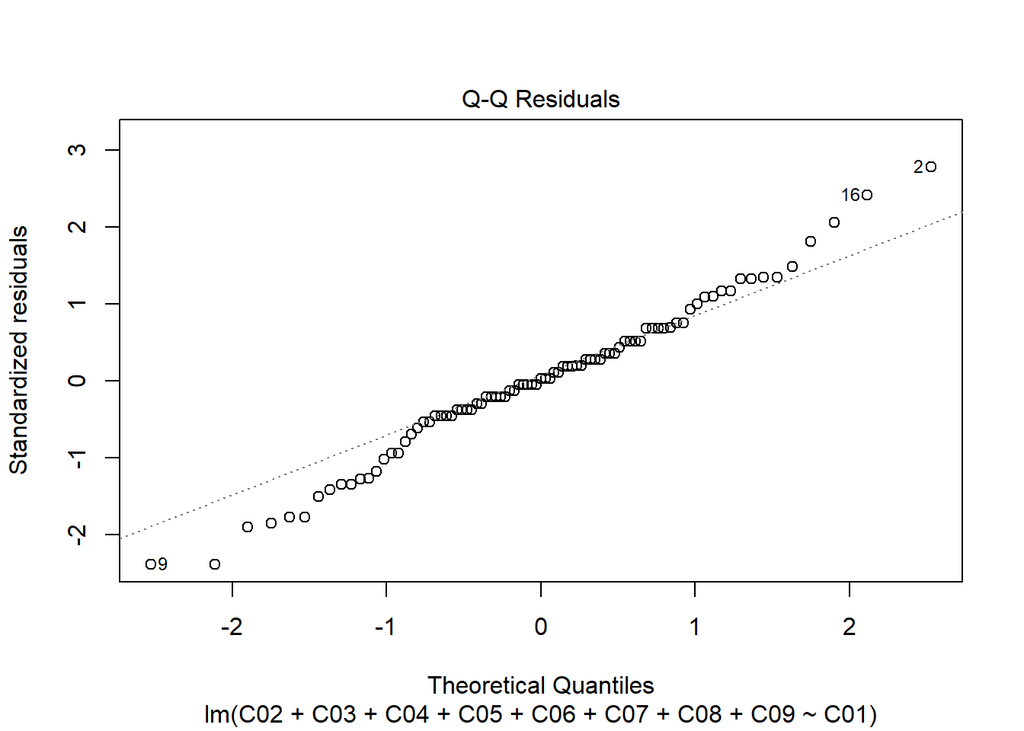

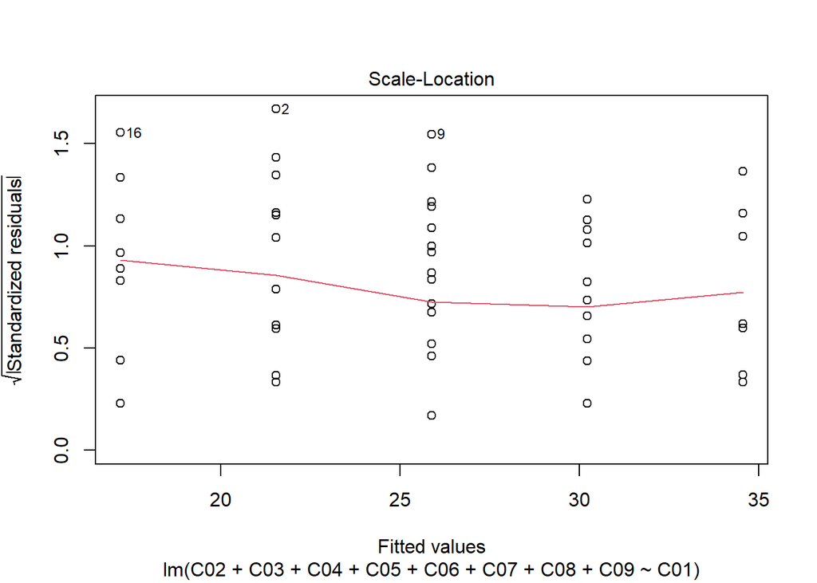

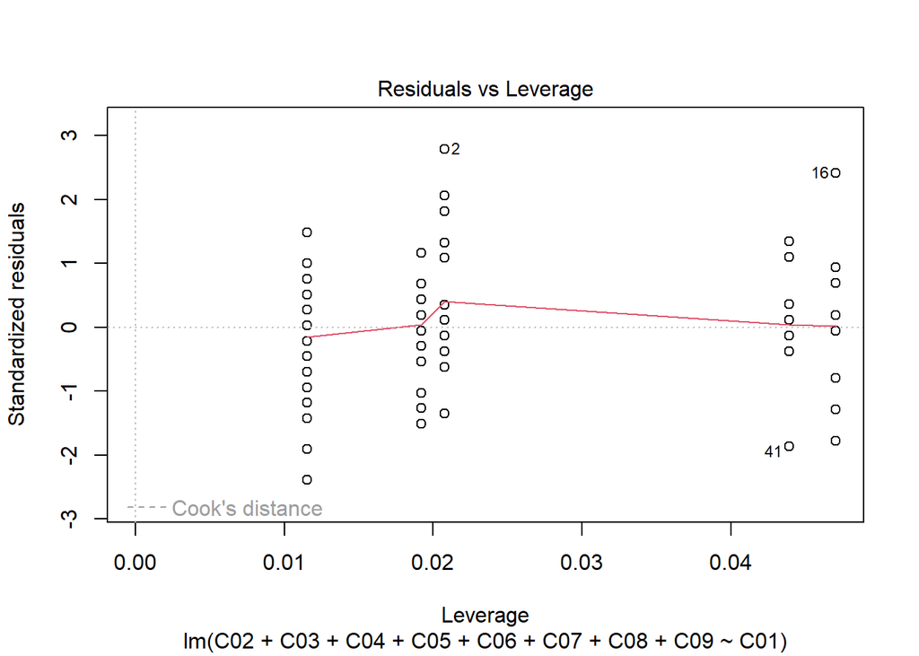

```r
plot(model)
```

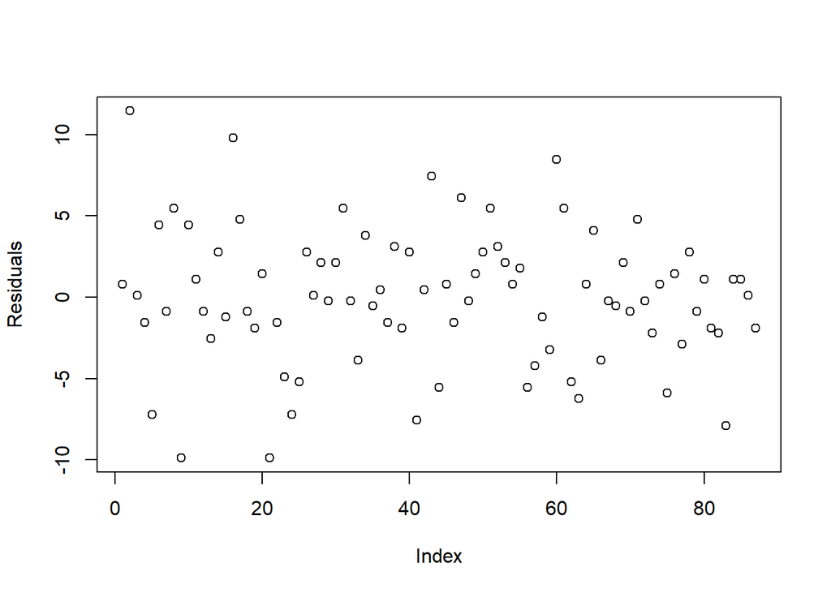

```r
Residuals = residuals(model)
plot(Residuals)
```

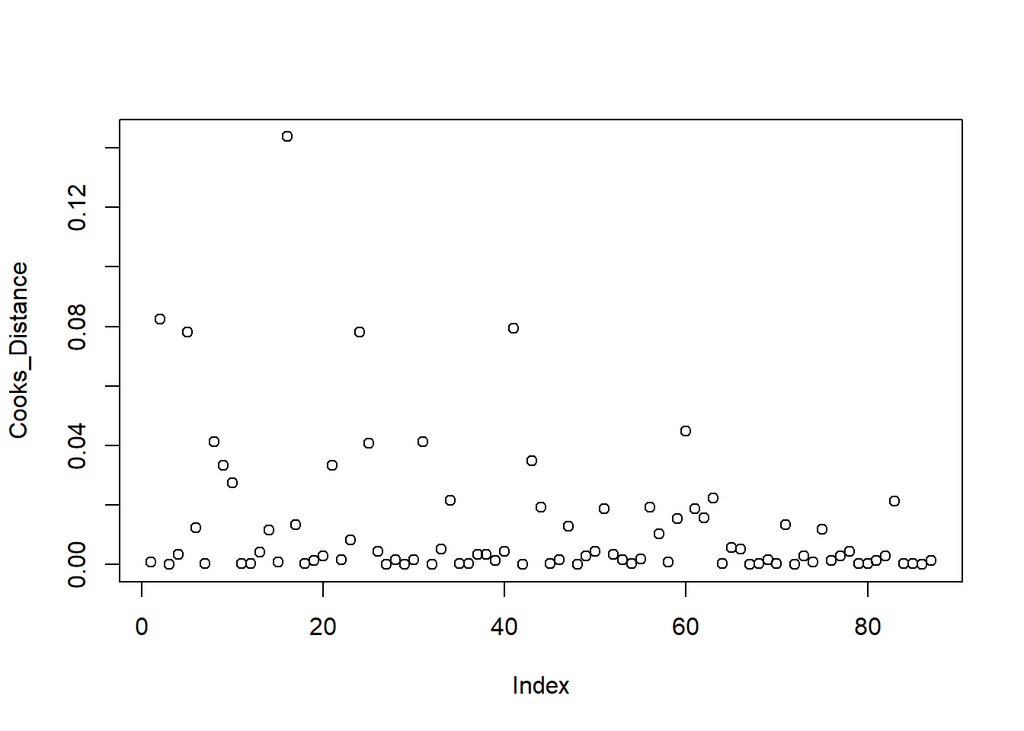

```r
Cooks_Distance = cooks.distance(model)
plot(Cooks_Distance)
```

```r
jarque.bera.test(Cooks_Distance)
```

```
##
##  Jarque Bera Test
##
## data:  Cooks_Distance
## X-squared = 617.8, df = 2, p-value < 2.2e-16
```

### Coefficients:

- **Intercept**: The intercept represents the estimated value of the response variable (`C02` through `C09`) when the predictor variable (`C01`) is zero. In this case, it’s estimated to be 12.8776.
- **C01**: The coefficient for `C01` represents the estimated change in the response variable for a one-unit increase in `C01`. Here, a one-unit increase in `C01` is associated with an estimated increase of 4.3345 in the response variable (`C02` through `C09`).

### Statistical Significance:

- Both the intercept and the coefficient for `C01` are statistically significant at conventional significance levels (indicated by the `***` symbols). This means that the relationship between `C01` and the response variable is unlikely to be due to random chance alone.

### Model Fit:

- **Residuals**: The residuals represent the differences between the observed values of the response variable and the values predicted by the model. The summary statistics of the residuals show that they have a mean close to zero, indicating that the model is unbiased on average.
- **Residual Standard Error**: This represents the standard deviation of the residuals, which is approximately 4.154 in this case. It provides a measure of the typical deviation of observed values from the predicted values by the model.
- **Multiple R-squared**: This statistic (0.6014) indicates the proportion of variance in the response variable explained by the predictor variable(s) (`C01`). In this case, approximately 60.14% of the variability in the response variable is explained by `C01`.
- **Adjusted R-squared**: This is a version of the R-squared statistic that adjusts for the number of predictor variables in the model. It penalizes the R-squared value for each additional predictor variable. Here, the adjusted R-squared is 0.5967.
- **F-statistic**: This statistic tests the overall significance of the model. The large F-statistic (128.3) and the associated very small p-value indicate that the model as a whole is statistically significant.

In summary, the model suggests that `C01` has a significant and positive effect on the response variable (`C02` through `C09`), with each unit increase in `C01` associated with an estimated increase of 4.3345 units in the response variable. The model explains approximately 60.14% of the variability in the response variable, and the model as a whole is statistically significant.